# SML201 Chapter 2.3

EDA: Part II

Daisy Huang

Fall 2019

# R functions covered

- Functions/techniques that help you to get familiar with the dataset: `nrow()`, `ncol()`’
- Create a function: `function(input.variable1 = , input.variable2 = ,...){...}`
- Statistic functions: `tapply(X = , INDEX = , FUN = )`, `cor(x = , y = )`
- Data manipulation: `merge(x = , y = , by = , by.x = , by.y = , all = , all.x = , all.y = )`, `mutate()` in `dplyr` package,
- Graphical summary functions: `boxplot(y ~ grp, xlab = , ylab = , main = , names = , ...)`, plot(x = , y = , xlab = , ylab = , main = ,…)
- Graphical options: `par(mfrow = c(..., ...))`, `boxplot(..., ylab = ..., main = ...)`

# Introduction

In the last chapter we talked about how to manipulate vectors and data frames in R and we also learnt various statistics that are useful to extract summary information from a dataset. With these tools we were able to answer a lot of interesting questions about the Titanic passengers by manipulating the columns of the Titanic dataset one at a time. However, more (interesting) questions can be answered if we can use multiple columns of the dataset.

# Read in the dataset

```r
t.ship =
  read.csv(file =
  '/Users/billhaarlow/Desktop/SML201/titanic.csv')
```

We should refresh our memory on the properties of the dataset.

```r
class(t.ship)  # this tells me what kind of R object this dataset is
[1] "data.frame"
dim(t.ship)  # 891 rows by 12 columns
[1] 891  12
```

```r
head(t.ship)  # look at the first 6 (by default) rows of an object
```

|  | PassengerId | Survived | Pclass | Name | Sex | Age | SibSp | Parch | Ticket | Fare | Cabin | Embarked |
| --- | --- | --- | --- | --- | --- | --- | --- | --- | --- | --- | --- | --- |
| 1 | 1 | 0 | 3 | Braund, Mr. Owen Harris | male | 22 | 1 | 0 | A/5 21171 | 7.2500 |  | S |
| 2 | 2 | 1 | 1 | Cumings, Mrs. John Bradley (Florence Briggs Thayer) | female | 38 | 1 | 0 | PC 17599 | 71.2833 | C85 | C |
| 3 | 3 | 1 | 3 | Heikkinen, Miss. Laina | female | 26 | 0 | 0 | STON/O2. 3101282 | 7.9250 |  | S |
| 4 | 4 | 1 | 1 | Futrelle, Mrs. Jacques Heath (Lily May Peel) | female | 35 | 1 | 0 | 113803 | 53.1000 | C123 | S |
| 5 | 5 | 0 | 3 | Allen, Mr. William Henry | male | 35 | 0 | 0 | 373450 | 8.0500 |  | S |
| 6 | 6 | 0 | 3 | Moran, Mr. James | male | NA | 0 | 0 | 330877 | 8.4583 |  | Q |

```r
str(t.ship, strict.width = "cut")
'data.frame':   891 obs. of  12 variables:
 $ PassengerId: int  1 2 3 4 5 6 7 8 9 10 ...
 $ Survived   : int  0 1 1 1 0 0 0 0 1 1 ...
 $ Pclass     : int  3 1 3 1 3 3 1 3 3 2 ...
 $ Name       : Factor w/ 891 levels "Abbing, Mr. Anthony",....
 $ Sex        : Factor w/ 2 levels "female","male": 2 1 1 1 2..
 $ Age        : num  22 38 26 35 35 NA 54 2 27 14 ...
 $ SibSp      : int  1 1 0 1 0 0 0 3 0 1 ...
 $ Parch      : int  0 0 0 0 0 0 0 1 2 0 ...
 $ Ticket     : Factor w/ 681 levels "110152","110413",..: 52..
 $ Fare       : num  7.25 71.28 7.92 53.1 8.05 ...
 $ Cabin      : Factor w/ 148 levels "","A10","A14",..: 1 83 ..
 $ Embarked   : Factor w/ 4 levels "","C","Q","S": 4 2 4 4 4 ..
```

**Will class or gender affect the survival rate? How big are the gaps between the socioeconomic classes?**

- What is the survival rate for each ticket class? Are the rates about the same across the three ticket classes?

```r
# number of survivals in each ticket class
numerator = table(t.ship$Pclass, t.ship$Survived)
# this produces a contingency table
dim(numerator)
[1] 3 2
class(numerator)
[1] "table"

# number of people in each ticket class
denominator = table(t.ship$Pclass)  # 1-dimensional array
dim(denominator)
[1] 3
class(denominator)
[1] "table"

# The following will not work since array operations require
# the two arrays to be in the same dimension
# numerator/denominator

# however, you can divide an array by a vector if the
# dimensions make sense
table(t.ship$Pclass, t.ship$Survived)/as.vector(table(t.ship$Pclass))

            0         1
  1 0.3703704 0.6296296
  2 0.5271739 0.4728261
  3 0.7576375 0.2423625


# In short, you cannot operate on two arrays unless both
# arrays have exactly the same dimensions; e.g.,
# table(t.ship$Pclass, t.ship$Survived)/table(t.ship$Pclass)
```

As we can see above, the procedure gets complicated if we want to rely on using the function `table()` only. Fortunately, there is a function `tapply()` that is suitable for this kind of tasks. Here is how we would use the function `tapply()` to accomplish the same task. Note that you can obtain the answer with only ONE line of code!

```r
tapply(X = t.ship$Survived, INDEX = t.ship$Pclass, FUN = mean)
        1         2         3
0.6296296 0.4728261 0.2423625
```

# Exercise

Question 1. What is the survival rate for each sex? Are the rates about the same?

```r
tapply(t.ship$Survived, INDEX = t.ship$Sex, FUN = mean)
   female      male
0.7420382 0.1889081
```

The survival rate is a lot higher for women.

Question 2. What is the average and median price for each ticket class?

```r
# average prices
tapply(t.ship$Fare, INDEX = t.ship$Pclass, FUN = mean)
       1        2        3
84.15469 20.66218 13.67555

# how big are the gaps?
avg.tic.price = tapply(t.ship$Fare, INDEX = t.ship$Pclass, FUN = mean)
(avg.tic.price[1:2] - avg.tic.price[2:3])/avg.tic.price[2:3]
       1        2
3.072885 0.510885
# 1st class tickets are about 3 times more than the 2nd class
# tickets on average 2st class tickets are about 150% of the
# 2nd class tickets on average


# median prices
tapply(t.ship$Fare, INDEX = t.ship$Pclass, FUN = median)
      1       2       3
60.2875 14.2500  8.0500

med.tic.price = tapply(t.ship$Fare, INDEX = t.ship$Pclass, FUN = median)
(med.tic.price[1:2] - med.tic.price[2:3])/med.tic.price[2:3]
        1         2
3.2307018 0.7701863
# 1st class tickets are about 3 times more than the 2nd class
# tickets in terms of the median 2st class tickets are almost
# 180% of the 2nd class tickets in terms of the median
```

# Multiple histograms

**Will age affect the survival rate?**

A natural way to approach this question would be to see if there is a relationship between `Age` and the average survival rate for people of that age.

```r
# average survival rate for each age
s.rate.by.age = tapply(X = t.ship$Survived, INDEX = t.ship$Age,
    FUN = mean)
```

We can use a scatterplot to investigate this relationship.

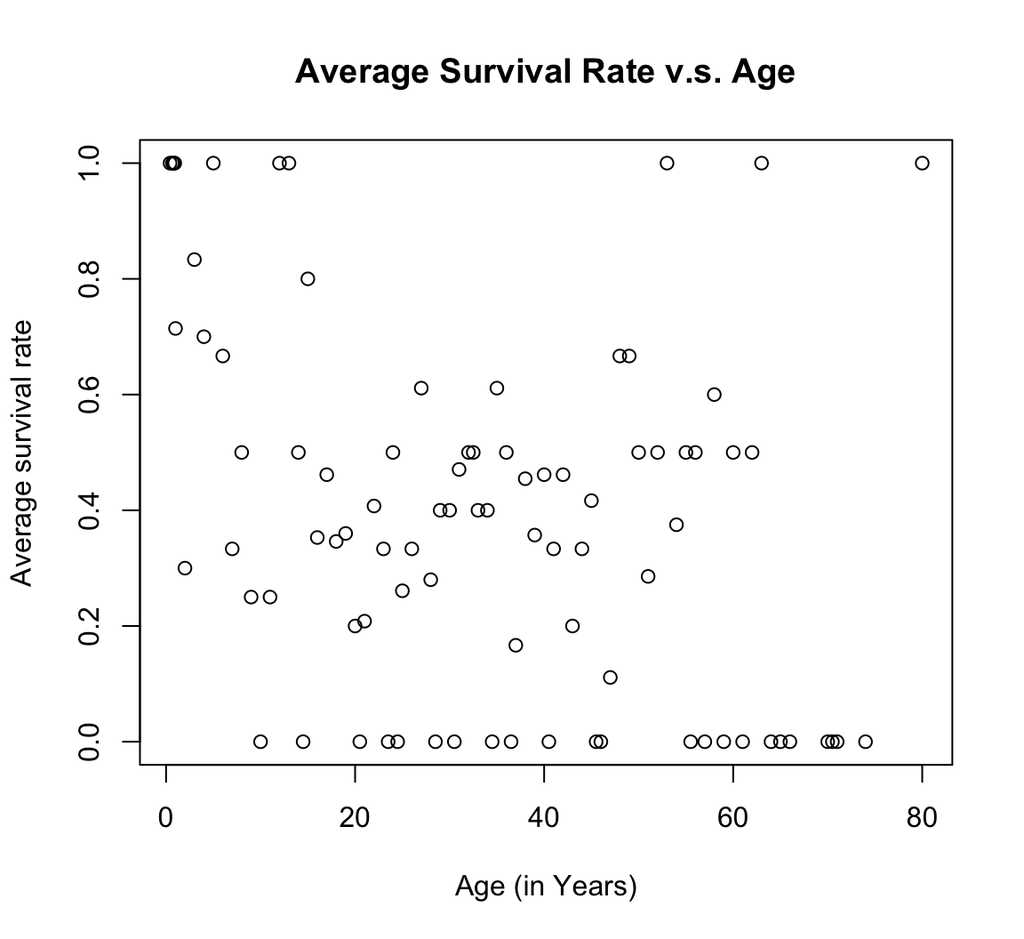

```r
plot(x = as.numeric(names(s.rate.by.age)), y = s.rate.by.age,
    main = "Average Survival Rate v.s. Age", xlab = "Age (in Years)",
    ylab = "Average survival rate")
```

Note that this does not tell us how many people we have in each age group; thus, it is difficult to say the 100% survival rate was the result due to having too few people in the age group or not. We can try looking at the problem from a slightly different angle by answering the following question.

Question 3. Can we compare the age distributions of the passengers between the survivors and the deceased?

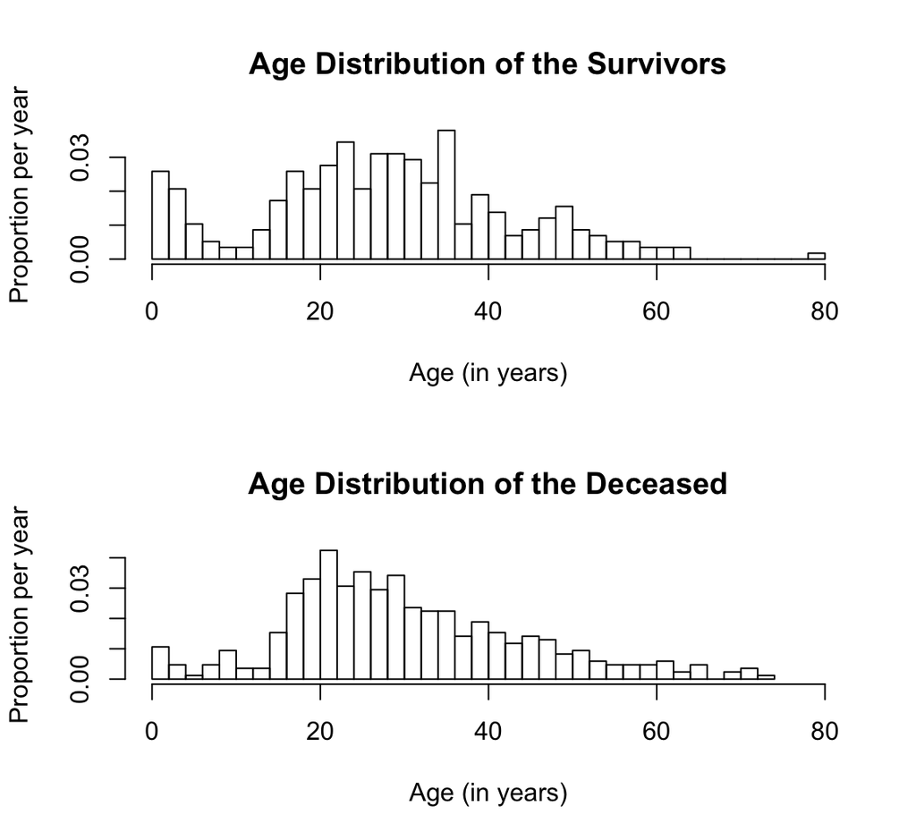

```r
# histograms
par(mfrow = c(2, 1))
hist(t.ship$Age[t.ship$Survived == 1], freq = F, breaks = 30,
    main = "Age Distribution of the Survivors", xlab = "Age (in years)",
    ylab = "Proportion per year", xlim = c(0, 80))
hist(t.ship$Age[t.ship$Survived == 0], freq = F, breaks = 30,
    main = "Age Distribution of the Deceased", xlab = "Age (in years)",
    ylab = "Proportion per year", xlim = c(0, 80))
```

# Side-by-side boxplots

Previously, we learnt how to interpret a boxplot and how to draw a boxplot for one variable. We also learnt that a boxplot is a graphical way to display the five number summaries. Because of this a boxplot does not give us as much detailed information about the distribution of the data as a histogram; however, when comparing multiple datasets using side-by-side boxplots makes it convenient to detect any shifts in the distributions.

To make side-by-side boxplots the `boxplot()` function takes its input arguments in this form

> boxplot(y ~ grp)

where `grp` will be converted into a factor (a categorical variable) if not already so; `R` uses `grp` to divide your dataset into different groups/subsets–think about what the `INDEX` argument in `tapply()` does.

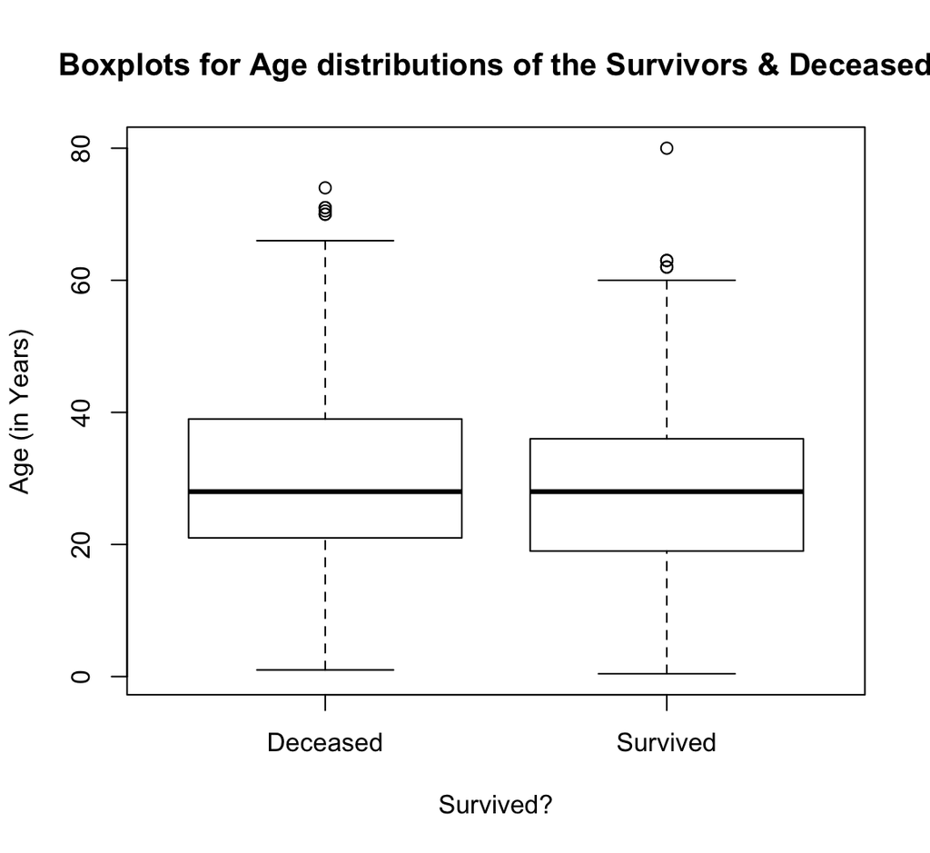

```r
# boxplots

par(mfrow = c(1, 1))
boxplot(t.ship$Age ~ t.ship$Survived, names = c("Deceased", "Survived"),
    main = "Boxplots for Age distributions of the Survivors & Deceased",
    xlab = "Survived?", ylab = "Age (in Years)")
```

# Creating functions

User-defined functions are often used to reduce the number of lines of code needed when one wants to repeat a set of task many times on different R objects. This makes the code easier to read and reduces the chance of having errors in the code compared to using the copy-and-paste method.

```r
Function_name = function(input_var) {
    # a set of tasks performed on the input_var return(result to
    # output)
}

RaiseToAPower = function(x, power) {
    y = x^power
    return(y)
}

k = RaiseToAPower(2, 3)
k
[1] 8
```

Question 4. Can we create a function to calculate the survival rate and median age when users specify the gender and the ticket class of the group of passengers?

```r
InfoOnGenderPclass = function(gender, ticket.class) {
    # `gender` options: 'female' and 'male'; `ticket.class`
    # options: 1-3
    subs.titanic = t.ship[t.ship$Sex == gender & t.ship$Pclass ==
        ticket.class, ]
    survival.rate = mean(subs.titanic$Survived)
    return(c(survival.rate = mean(subs.titanic$Survived), median.age = median(subs.titanic$Age,
        na.rm = T)))
}

# run to check the output of the function
InfoOnGenderPclass(gender = "female", ticket.class = 2)
survival.rate    median.age
    0.9210526    28.0000000
InfoOnGenderPclass(gender = "male", ticket.class = 3)
survival.rate    median.age
    0.1354467    25.0000000

# assign output to a new variable
male3.s.rate.med.age = InfoOnGenderPclass(gender = "male", ticket.class = 3)
```

# Some interesting facts about this dataset

Someone asked in a previous lecture why the numbers for the variable `Fare` have 4 digits after the decimal. I did some research and found out that the ticket prices were in the format of Lsd; i.e., they are in the format of Pounds-Shillings-Pence. (https://www.encyclopedia-titanica.org/titanic-survivor/annie-moore-ward.html)

Note that

- 1 pound = 240 pence
- 1 shilling = 12 pence
- 1 pound = 20 shillings

Thus, in 1912 the British currency was not in the metric system (https://en.wikipedia.org/wiki/%C2%A3sd).

Also, there are discussions online about what exactly the definition for the variable `Fare` should be and there seems to be a lot of confusions. (You can see some of the discussions here https://www.kaggle.com/c/titanic/discussion/3916)

After reading a few of the webpages for Titanic passengers I was able find out the definition for `Fare`. For example, on the webpage for the passenger Ann Moore Ward (https://www.encyclopedia-titanica.org/titanic-survivor/annie-moore-ward.html) it says

> For the return to the USA Annie boarded the Titanic…with Mrs Cardeza, her son Thomas and his manservant Gustave Lesueur and the entourage travelled on **ticket number 17755** which cost the princely **sum** of £512, 6s, 7d.

Thus, the figures shown for the variable `Fare` are not for individual passengers but for the group of passengers sharing the same ticket number!

We will figure out the single ticket prices ourselves.

Let’s create a new data frame that includes a column for the single ticket prices.

First, let’s find out how many people there are for each ticket number.

```r
# the output for table() is a 1-dimensional array however, it
# is much easier to work with vectors; thus, we want to
# convert the output into a vector; note that `as.vector()`
# will remove the names of the elements in the table by
# default.

# here we want to find out the number of passengers for each
# ticket number
no.grp.members = as.vector(table(t.ship$Ticket))
head(no.grp.members)
[1] 3 3 2 1 1 1
head(table(t.ship$Ticket))

110152 110413 110465 110564 110813 111240
     3      3      2      1      1      1
```

Note that the length of `no.grp.members` is smaller than the number of rows in `t.ship`. Is this expected?

```r
# How many unque ticket numbers there are?
length(no.grp.members)
[1] 681

# How many passengers?
nrow(t.ship)
[1] 891
```

# Merging datasets

We will use the function `merge()`. Let’s create a data frame for ticket numbers and group member sizes for merging.

```r
ticket.member = data.frame(Ticket = names(table(t.ship$Ticket)),
    grp.member.ct = no.grp.members)
head(ticket.member)
```

|  | Ticket | grp.member.ct |
| --- | --- | --- |
| 1 | 110152 | 3 |
| 2 | 110413 | 3 |
| 3 | 110465 | 2 |
| 4 | 110564 | 1 |
| 5 | 110813 | 1 |
| 6 | 111240 | 1 |

```r
# `by.x` is the column in `x` that is used for the matching
# `by.y` is the column in `y` that is used for the matching

t.ship.merged = merge(x = t.ship, y = ticket.member, by.x = "Ticket",
    by.y = "Ticket")

# Check that no one is missing
dim(t.ship.merged)
[1] 891  13
dim(t.ship)
[1] 891  12
```

# Adding additional columns to a data frame

```r
# load the package `dplyr` so that we can use the function
# `mutate()`
library(dplyr)

t.ship.complete = mutate(t.ship.merged, single.tic.price = Fare/grp.member.ct)

knitr::kable(head(t.ship.complete))
```

| Ticket | PassengerId | Survived | Pclass | Name | Sex | Age | SibSp | Parch | Fare | Cabin | Embarked | grp.member.ct | single.tic.price |
| --- | --- | --- | --- | --- | --- | --- | --- | --- | --- | --- | --- | --- | --- |
| 110152 | 258 | 1 | 1 | Cherry, Miss. Gladys | female | 30 | 0 | 0 | 86.50 | B77 | S | 3 | 28.83333 |
| 110152 | 760 | 1 | 1 | Rothes, the Countess. of (Lucy Noel Martha Dyer-Edwards) | female | 33 | 0 | 0 | 86.50 | B77 | S | 3 | 28.83333 |
| 110152 | 505 | 1 | 1 | Maioni, Miss. Roberta | female | 16 | 0 | 0 | 86.50 | B79 | S | 3 | 28.83333 |
| 110413 | 559 | 1 | 1 | Taussig, Mrs. Emil (Tillie Mandelbaum) | female | 39 | 1 | 1 | 79.65 | E67 | S | 3 | 26.55000 |
| 110413 | 263 | 0 | 1 | Taussig, Mr. Emil | male | 52 | 1 | 1 | 79.65 | E67 | S | 3 | 26.55000 |
| 110413 | 586 | 1 | 1 | Taussig, Miss. Ruth | female | 18 | 0 | 2 | 79.65 | E68 | S | 3 | 26.55000 |

# Checking the relationship between two variables

## Scatterplot

We have seen how we can investigate the relationship between two variables by using a scatterplot. Here we would like to see if there is a relationship between the number of members sharing the same ticket number and the number of parent/sibling/spouse/child companions.

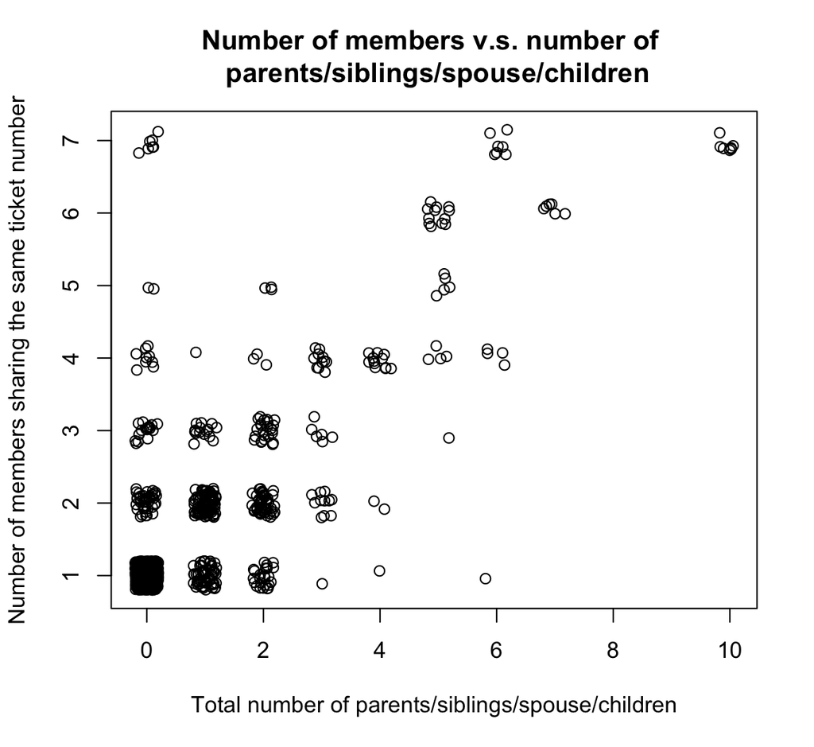

```r
plot(x = jitter(t.ship.complete$SibSp + t.ship.complete$Parch),
    y = jitter(t.ship.complete$grp.member.ct), xlab = "Total number of parents/siblings/spouse/children",
    ylab = "Number of members sharing the same ticket number",
    main = "Number of members v.s. number of \n parents/siblings/spouse/children")
```

Note that the trend of the relationship between the `x` and `y` variables is somewhat linear.